# JSC370 Midterm Project

## 0. Info

Github [repo](https://github.com/JustinZhaoOvO/JSC370_Midterm)

Team Member:

- Nanxin(Nathan) Li, 1009834734
- Boquan Zhao, 1010419343

## 1. Introduction

### Motivation

Video games are one of the most popular entertainment today, with millions of players spending large amounts of time playing games on platforms such as Steam, Xbox, etc, so it is interesting to ask what characteristics of a game are related to how long players actually spend playing it.

One useful way to measure player engagement is average playtime. Some games are designed to be played for many hours, while others are intended for shorter but also enjoyable experiences. Characteristics such as genre, price, release year, or popularity may influence how much time players spend in a game.

The goal of this project is to explore how different game characteristics are related to average playtime. Using data collected from public web APIs, we combine gameplay statistics and game metadata to investigate whether certain features of a game are associated with longer or shorter playtime.

### Database Introduction

The dataset used in this project combines information from two public APIs: [SteamSpy](https://steamspy.com/api.php) and [RAWG](https://rawg.io/apidocs).

SteamSpy provides aggregated statistics about 300000+ games available on the Steam. These statistics are estimated from publicly available player profile data. From SteamSpy, we obtain several variables related to player engagement and popularity, including the estimated number of owners (owners), the number of positive reviews (positive) and negative reviews (negative), the average lifetime playtime measured in minutes (average_forever), and the game price in US cents(price).

The RAWG Video Games Database API provides additional metadata about 500000+ games across multiple platforms, including the release date of the game (released), genre classifications (genres), critic scores (metacritic), and supported platforms (platforms).

In this analysis, we use average playtime as the outcome variable, and consider the relationship between average playtime and the following variables:

Game genre (genres): describe the category of the game, such as action, strategy, or role-playing.

Game price (price): represent the listed price of the game on Steam.

Release year(released): the release date.

Game popularity(owners): the estimated range of owners.

### Research Questions

Specifically, we will focus on the following research questions:

- How does game playtime differ across game genres (genres)?
- Is game price (price) associated with average playtime (average_forever)?
- How does game release year derived from the release date (released) relate to playtime (average_forever)?
- Is game popularity measured by number of owners (owners) associated with playtime (average_forever)?

## 2. Methods

### Data acquisition

The data used in this project were collected from two public web APIs: the SteamSpy API and the RAWG Video Games Database API. SteamSpy was used as the primary source of game-level engagement statistics, while RAWG was used to obtain additional metadata such as genre and release year.

We first queried the SteamSpy API using the `all` endpoint across multiple pages. This endpoint returns price, estimated number of owners, review counts, average lifetime playtime, etc for games available on the Steam platform. It contains more than 300000 games. But due to the API only allows one request for one page per minute, for convenience, we only queried the first 20 pages of the API results to obtain a broad sample of games. There are 1000 games per page, so we fetced totally 20000 games.

To obtain additional metadata, we use the game titles from the SteamSpy dataset to query the RAWG API. Since the API has a request limit of 20000 requests per three months, we randomly sampled 1000 games from the SteamSpy dataset to query the RAWG API. Among these 1000 queried games, RAWG API were successfully retrieved for 996 games. There are four games that the RAWG API failed to retrieve: `BLADECHIMERA`, `RutonyChat`, `CatTuber`, and `VoiceAttack`. We also manually searched these four games on RAWG website and found that these four games are missing on the RAWG database instead of due to name format mismatch. For each game title, the RAWG API returns information including release date and genre classifications.

To ensure reproducibility and avoid repeatedly calling external APIs when rendering the report, the downloaded API results were stored locally as cache files. When cached files already exist, the data are loaded directly from disk instead of sending new API requests.

### Data cleaning and wrangling

After collecting the raw API data, we perform several cleaning and preprocessing steps to prepare the data for analysis.

First, since there are some duplicated game titles in the SteamSpy dataset, we retained only games whose cleaned title appeared exactly once in the SteamSpy dataset. The duplicated game names are due to different records may share the same game name even though they correspond to different entries or versions. Since our workflow relies on game titles to query metadata from the RAWG API and to merge the datasets, keeping multiple records with the same title would create ambiguity in the mapping between games across the two sources. Therefore, we remove the duplicated game names records to keep the game name unique.

Next, we check the missing values, and there are no NaN values in the SteamSpy dataset. We also check the summary statistics of the numeric variables. We found that there are 3872 games out of 20000 with price 0, and 5307 games with average playtime 0. It is possible that these games are free, but a value of 0 minutes may reflect missing playtime estimates rather than true statistics, especially there are some famous games like `Grand Theft Auto IV: Complete Edition`, `Half-Life 2: Lost Coast`, etc. We also check the game names with empty string, and there are no such games. So we drop the games with average playtime 0 from the dataset at the end.

Also, we convert numeric variables such as price and average playtime into numeric formats. We convert Steam prices from cents to dollars, and average lifetime playtime from minutes to hours to improve interpretability.

The SteamSpy API reports the number of owners as a range (e.g. “100000..200000”) rather than an exact value. To obtain a numeric approximation of popularity, we convert each owner range to its midpoint.

Finally, we standardize game titles by removing punctuation, collapsing repeated whitespace, converting text to lowercase, and storing the cleaned title in a new column `name_clean`. We also apply the same title-standardization procedure to the RAWG results so that a consistent matching field can be used during the merge. This is neccessary because RAWG API using a fuzzy search algorithm to match game titles, so the game titles in the RAWG dataset may not be exactly the same as the game titles in the SteamSpy dataset.

For 996 RAWG records, there are 37 missing values in released data and 16 games with empty genre list. We drop the games with missing released data or empty genre list. Next, we convert release dates returned by RAWG into release years, and simplify genre lists by extracting the first listed genre as the primary genre.

Before cleaning and wrangling, SteamSpy dataset has 20000 records and RAWG dataset has 996 records, and after cleaning and wrangling, SteamSpy dataset reduced to 14366 records and RAWG dataset reduced to 946 records.

### Data integration

After cleaning and wrangling the SteamSpy and RAWG datasets separately, we merged the two sources using the standardized game title field `name_clean` using an inner join.

After merging, there are 865 games that are successfully matched across both APIs, which means there are 81 games not successfully matched even using the cleaned game titles `name_clean` for matching. This is due to the fuzzy search algorithm used by the RAWG API, some games exist in the SteamSpy data but not in the RAWG data, RAWG API still return a result but it is not always the correct game, resulting in some games being matched to the wrong game.

We also check the summary statistics of the merged dataset and found that there is one game with average playtime greater than 1000 hours, specifically, `WitchSpring3 Re:Fine - The Story of Eirudy` has a average playtime of 15918.67 hours, which is unlikely to be a valid data point, so we drop this record.

From the merged dataset, we kept the variables directly relevant to the research questions: average playtime, primary genre, price, estimated number of owners, and release year, and we renamed these variables in the final analysis dataset to `playtime`, `genre`, `price`, `owners`, and `release_year`.

Because the ownership variable is highly right-skewed, we also created a log-transformed version, `log_owners`, using log1p for use in later exploratory plots and analyses.

Finally, we performed a check of the missing values in the final analysis dataset and found no missing values at any column in the dataset.

Eventually, there are 864 games remaining in the merged dataset.

The following table shows the first 5 rows of the final analysis dataset:

|  | name | playtime | genre | price | owners | release_year | log_owners |
| --- | --- | --- | --- | --- | --- | --- | --- |
| 0 | HELLDIVERS 2 | 83.866667 | Action | 39.99 | 35000000.0 | 2024 | 17.370859 |
| 1 | Wallpaper Engine | 75.483333 | Casual | 3.99 | 35000000.0 | 2016 | 17.370859 |
| 2 | ARK: Survival Evolved | 202.516667 | Adventure | 14.99 | 35000000.0 | 2015 | 17.370859 |
| 3 | Path of Exile | 181.566667 | Indie | 0.00 | 35000000.0 | 2013 | 17.370859 |
| 4 | Naraka Bladepoint | 159.066667 | Massively Multiplayer | 0.00 | 15000000.0 | 2021 | 16.523561 |

### Exploratory analysis methods

Our exploratory analysis focuses on how average playtime relates to the main explanatory variables: genre, price, release year, and estimated number of owners.

We begin with summary statistics of the final merged dataset.

To understand the overall distribution of playtime, we: - Calculate summary measures such as the mean, median, and spread, together with a histogram of playtime. - Examine the distribution of the owners variable before and after log transformation to assess its right-skewness. - Summarize the number of games in each genre using a bar plot.

To address the first research question, which compares playtime across genres, we: - Use a violin plot to compare the distribution of playtime across genre groups, and also plot the mean and median playtime within each genre. - Use ANOVA to test whether mean playtime differs across genres overall.

For the remaining research questions, price, release year, and number of owners are treated as continuous variables. We: - Examine their pairwise relationships with playtime and with each other using a correlation matrix. - Use scatterplots with fitted trend lines to visualize the relationship between playtime and each continuous predictor.

To examine whether the relationship between price and playtime differs across game types, we: - Create faceted scatterplots of price versus playtime by genre.

## 3. Preliminary Results

#### Overall distribution of playtime

|  | playtime | price | owners | release_year | log_owners |
| --- | --- | --- | --- | --- | --- |
| count | 864.000000 | 864.000000 | 8.640000e+02 | 864.000000 | 864.000000 |
| mean | 13.526871 | 11.795544 | 6.395775e+05 | 2016.856481 | 12.098724 |
| std | 33.130965 | 12.273577 | 2.624068e+06 | 5.127370 | 1.305221 |
| min | 0.016667 | 0.000000 | 3.500000e+04 | 1990.000000 | 10.463132 |
| 25% | 2.650000 | 1.990000 | 7.500000e+04 | 2015.000000 | 11.225257 |
| 50% | 4.766667 | 9.990000 | 1.500000e+05 | 2017.000000 | 11.918397 |
| 75% | 11.579167 | 19.990000 | 3.500000e+05 | 2021.000000 | 12.765691 |
| max | 487.650000 | 69.990000 | 3.500000e+07 | 2025.000000 | 17.370859 |

|  | Statistic | Value |
| --- | --- | --- |
| 0 | Count | 864.00 |
| 1 | Mean | 13.53 |
| 2 | Median | 4.77 |
| 3 | Standard Deviation | 33.13 |
| 4 | Minimum | 0.02 |
| 5 | Maximum | 487.65 |

An examination of the key summary statistics of playtime shows substantial variability in the data. The standard deviation is larger than the mean, indicating a high level of dispersion and suggesting that the distribution is unlikely to be normal. The playtime distribution also appears to be strongly right-skewed, as the mean exceeds the 75th percentile, implying that a small number of games have very large playtime values that pull the mean upward. No clearly impossible observations are present in the dataset. For example, the minimum playtime (0.0167 hours) is plausible, as it may correspond to a user who has just purchased the game and has not meaningfully played it yet.

The playtime-histogram is used to evaluate the distribution of the playtime, thus we can evaluate the skewness and frequent observations.

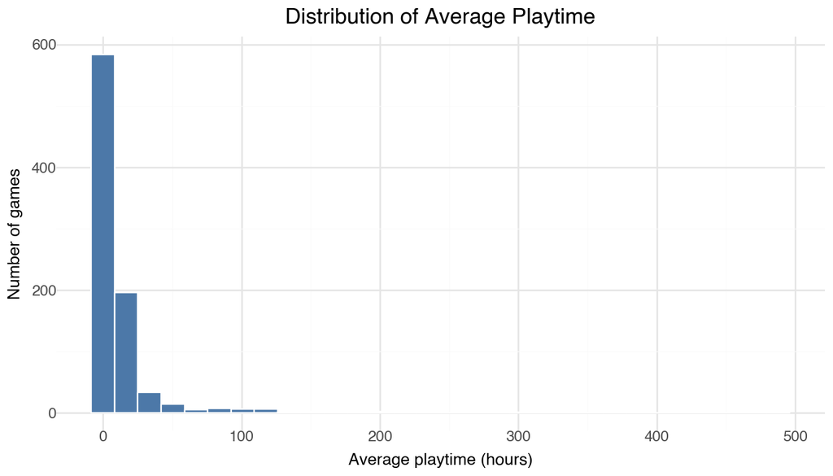

The histogram shows that the distribution of average playtime is highly right-skewed. Most games have relatively short average playtimes, with the majority concentrated below 20 hours. A small number of games exhibit substantially larger playtimes, creating a long right tail in the distribution. These high-playtime games likely correspond to large RPG or open-world titles. Overall, the distribution suggests that playtime data are not normally distributed and are dominated by a few high-value observations.

#### Distribution of owners before and after log transformation

Those 2 histograms are used to compare the distirbution of the number of owners before and after the transformation, thus we can conclude the effectiveness of the approach.

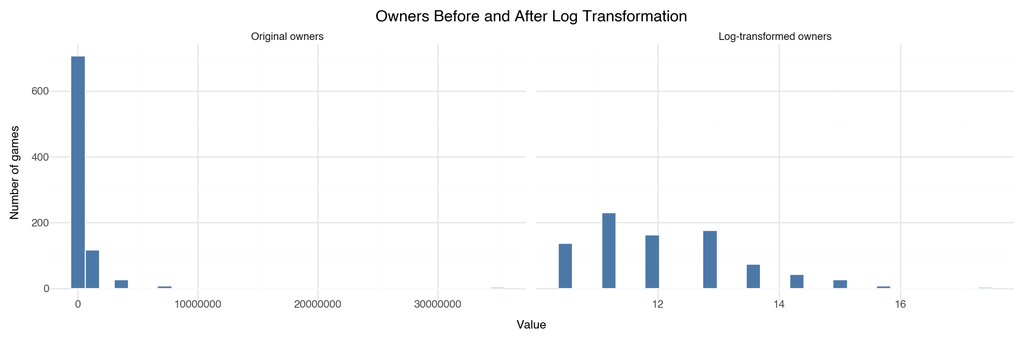

The distribution of game owners is highly right-skewed in its original scale, with most games having relatively small numbers of owners while a small number of games have extremely large player bases. This creates a long right tail and compresses the majority of observations near the lower end of the distribution. After applying a log transformation, the distribution becomes substantially more symmetric and spread out. The transformation reduces the influence of extreme values and makes the distribution more suitable for visualization and further statistical modeling.

The table below shows the transformed results of number of users follows a better distribution.

|  | Variable | Mean | Median | Standard Deviation | Skewness |
| --- | --- | --- | --- | --- | --- |
| 0 | owners | 639577.55 | 150000.00 | 2624067.84 | 11.01 |
| 1 | log_owners | 12.10 | 11.92 | 1.31 | 0.94 |

#### Distribution of games across genres

The count plot(bar) allows us to understand the number of observations within each genre categroy, thus we can examinate the sampling bias.

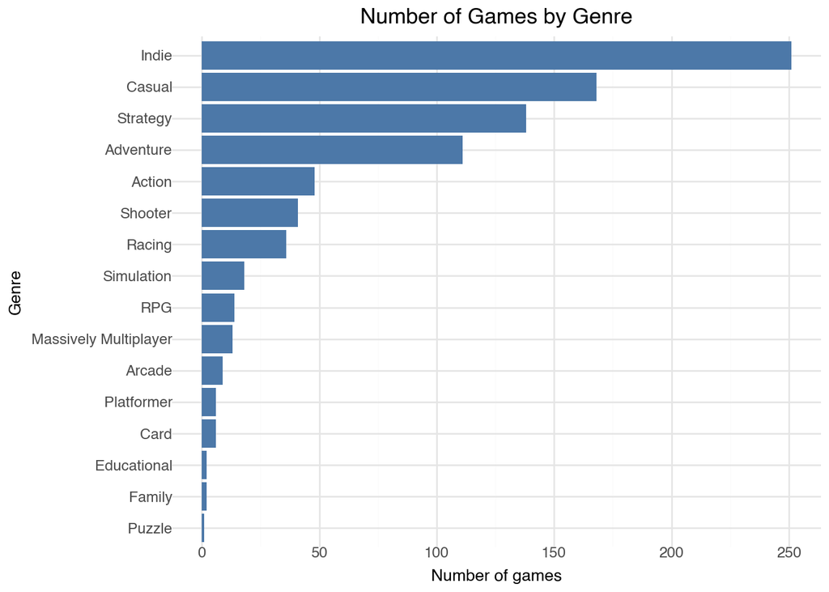

The bar chart illustrates the composition of the dataset across different game genres. Indie games constitute the largest share, followed by Casual, Strategy, and Adventure titles. In contrast, several genres such as Educational, Family, and Puzzle are only sparsely represented. This indicates a clear genre imbalance within the dataset, where certain categories dominate while others appear only rarely. Such imbalance may reflect broader trends in the game market, but it may also introduce potential sampling bias, meaning that analyses based on this dataset could disproportionately reflect the characteristics of more common genres like Indie and Casual games. Which means potential risk in applyting entropy-based classification models in the future.

#### Playtime across genres

The genre vs playtime plot allows us to study the differenceses of distribution of playtime across different genres.

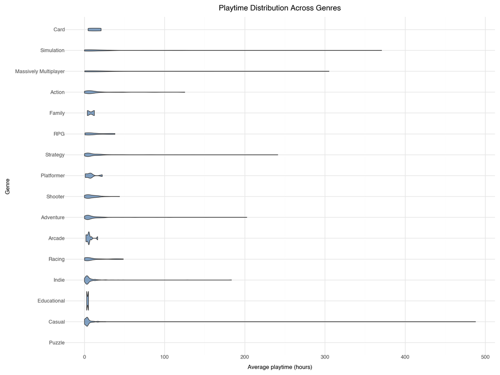

The violin plot shows that playtime distributions differ substantially across genres. Most genres are right-skewed, with a large concentration of games having relatively short playtimes and a few titles exhibiting extremely long playtimes. Genres such as Simulation, Massively Multiplayer, and Strategy tend to have longer playtime tails, while genres like Puzzle and Educational display shorter and more concentrated playtime distributions.

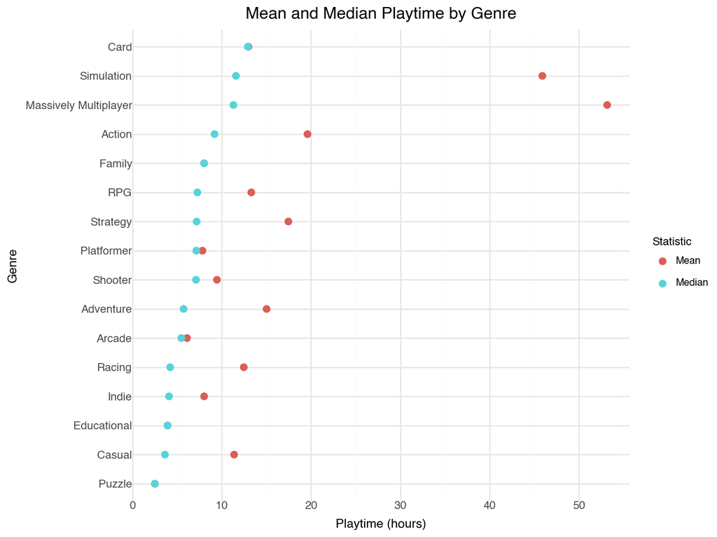

The mean playtime is generally higher than the median across most genres, indicating right-skewed playtime distributions. This pattern suggests that a small number of games with very long playtimes increase the average values. Genres such as Massively Multiplayer and Simulation exhibit particularly large gaps between the mean and median, suggesting strong tail beahavior.

The ANOVA test is used to examinate whether there’s a significant differences in average playtime across different game genres.

|  | Test | F statistic | p-value |
| --- | --- | --- | --- |
| 0 | One-way ANOVA | 3.6221 | 0.0 |

The p-value obtained from the one-way ANOVA test suggests that there are significant differences in average playtime across different game genres. This indicates that at least one genre has a mean playtime that differs from the others.

To further investigate which specific genre pairs differ, we propose conducting pairwise two-sample t-tests between genres and visualizing the resulting p-values using a heatmap.

|  | Action | Adventure | Arcade | Card | Casual | Educational | Family | Indie | Massively Multiplayer | Platformer | RPG | Racing | Shooter | Simulation | Strategy |
| --- | --- | --- | --- | --- | --- | --- | --- | --- | --- | --- | --- | --- | --- | --- | --- |
| Action | 1.0000 | 0.3679 | 0.0040 | 0.2025 | 0.1241 | 0.0009 | 0.1363 | 0.0113 | 0.2125 | 0.0341 | 0.2700 | 0.1553 | 0.0270 | 0.2362 | 0.6732 |
| Adventure | 0.3679 | 1.0000 | 0.0052 | 0.6106 | 0.3863 | 0.0007 | 0.3121 | 0.0206 | 0.1578 | 0.1061 | 0.7130 | 0.4990 | 0.0720 | 0.1634 | 0.5314 |
| Arcade | 0.0040 | 0.0052 | 1.0000 | 0.0619 | 0.1320 | 0.2981 | 0.7374 | 0.3170 | 0.0868 | 0.6318 | 0.0882 | 0.0368 | 0.1062 | 0.0763 | 0.0004 |
| Card | 0.2025 | 0.6106 | 0.0619 | 1.0000 | 0.7075 | 0.0246 | 0.4440 | 0.1469 | 0.1386 | 0.2501 | 0.9458 | 0.8933 | 0.2919 | 0.1390 | 0.2695 |
| Casual | 0.1241 | 0.3863 | 0.1320 | 0.7075 | 1.0000 | 0.0315 | 0.5900 | 0.3211 | 0.1252 | 0.4366 | 0.6950 | 0.7903 | 0.5771 | 0.1225 | 0.1487 |
| Educational | 0.0009 | 0.0007 | 0.2981 | 0.0246 | 0.0315 | 1.0000 | 0.5166 | 0.0681 | 0.0747 | 0.2899 | 0.0301 | 0.0066 | 0.0252 | 0.0628 | 0.0001 |
| Family | 0.1363 | 0.3121 | 0.7374 | 0.4440 | 0.5900 | 0.5166 | 1.0000 | 0.9997 | 0.1019 | 0.9750 | 0.4285 | 0.4823 | 0.8003 | 0.0952 | 0.2132 |
| Indie | 0.0113 | 0.0206 | 0.3170 | 0.1469 | 0.3211 | 0.0681 | 0.9997 | 1.0000 | 0.0988 | 0.9574 | 0.1931 | 0.1221 | 0.4300 | 0.0901 | 0.0019 |
| Massively Multiplayer | 0.2125 | 0.1578 | 0.0868 | 0.1386 | 0.1252 | 0.0747 | 0.1019 | 0.0988 | 1.0000 | 0.0989 | 0.1427 | 0.1337 | 0.1089 | 0.8268 | 0.1839 |
| Platformer | 0.0341 | 0.1061 | 0.6318 | 0.2501 | 0.4366 | 0.2899 | 0.9750 | 0.9574 | 0.0989 | 1.0000 | 0.2767 | 0.2750 | 0.6514 | 0.0908 | 0.0360 |
| RPG | 0.2700 | 0.7130 | 0.0882 | 0.9458 | 0.6950 | 0.0301 | 0.4285 | 0.1931 | 0.1427 | 0.2767 | 1.0000 | 0.8538 | 0.3434 | 0.1446 | 0.3755 |
| Racing | 0.1553 | 0.4990 | 0.0368 | 0.8933 | 0.7903 | 0.0066 | 0.4823 | 0.1221 | 0.1337 | 0.2750 | 0.8538 | 1.0000 | 0.3055 | 0.1328 | 0.1878 |
| Shooter | 0.0270 | 0.0720 | 0.1062 | 0.2919 | 0.5771 | 0.0252 | 0.8003 | 0.4300 | 0.1089 | 0.6514 | 0.3434 | 0.3055 | 1.0000 | 0.1021 | 0.0101 |
| Simulation | 0.2362 | 0.1634 | 0.0763 | 0.1390 | 0.1225 | 0.0628 | 0.0952 | 0.0901 | 0.8268 | 0.0908 | 0.1446 | 0.1328 | 0.1021 | 1.0000 | 0.1974 |
| Strategy | 0.6732 | 0.5314 | 0.0004 | 0.2695 | 0.1487 | 0.0001 | 0.2132 | 0.0019 | 0.1839 | 0.0360 | 0.3755 | 0.1878 | 0.0101 | 0.1974 | 1.0000 |

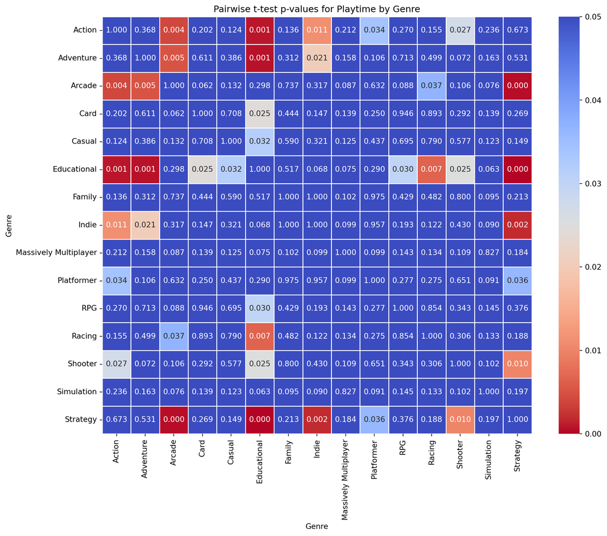

The heatmap displays the p-values from pairwise t-tests comparing the mean playtime between different game genres. Cells with smaller p-values (shown in red) indicate stronger evidence that the mean playtime differs significantly between the corresponding genres. In contrast, larger p-values (blue) suggest that the average playtimes are not significantly different.

Several genre pairs exhibit statistically significant differences in playtime (p < 0.05), particularly involving genres such as Educational, Strategy, and Arcade, which tend to show lower p-values when compared with other genres. This suggests that the typical gameplay duration in these genres may differ substantially from that of other categories.

However, many genre pairs display relatively large p-values, indicating that their average playtimes are not statistically distinguishable. Overall, the results suggest that while some genres have significantly different engagement patterns, many genres share similar playtime characteristics.

#### Continuous variables and playtime

The correlation matrix is used to examinate the correlation between the interested features.

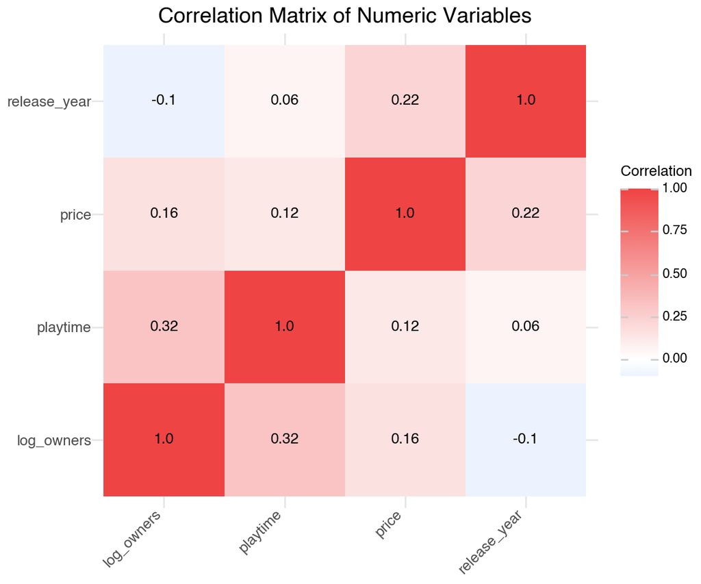

The correlation matrix shows generally weak relationships among the numeric variables. The strongest correlation is between log_owners and playtime (r ≈ 0.32), suggesting that games with longer playtimes tend to have more owners. Other correlations are relatively small, indicating limited linear relationships between price, release year, and the other variables.

The scatter plot and the line of best fit is used to examinate the relationships between playtime and the continuous predictors

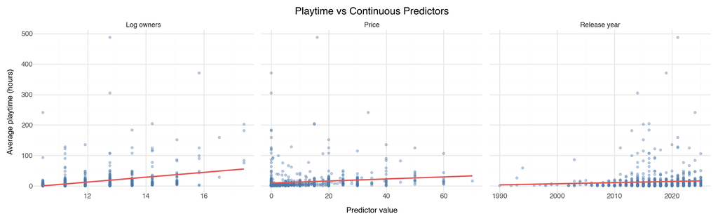

The scatter plots suggest weak relationships between playtime and the continuous predictors. Log owners shows the clearest positive association with playtime, indicating that games with more owners tend to have longer playtimes. In contrast, price and release year exhibit only very weak trends, with substantial variability in playtime across their ranges.

The wide dispersion of points around the trend lines suggests that these predictors alone may not fully explain the variability in playtime, indicating that additional factors such as genre or game design characteristics may also play important roles.

#### Faceted scatterplots by genre

The line of best fit in each graph shows relationship between game price and average playtime across several of the most common genres.

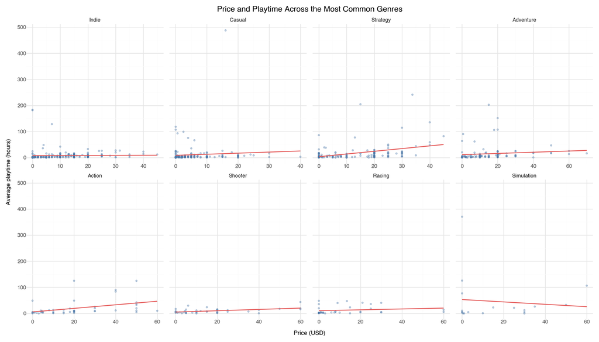

The faceted scatter plots illustrate the relationship between game price and average playtime across several of the most common genres. Overall, the relationship between price and playtime appears weak and highly variable within most genres.

For genres such as Strategy, Action, and Adventure, the trend lines show a slight positive association, suggesting that more expensive games in these categories may tend to have somewhat longer playtimes. However, the data points remain widely dispersed, indicating substantial variability in playtime regardless of price.

In contrast, genres such as Simulation show little or even slightly negative association between price and playtime, suggesting that higher-priced games do not necessarily provide longer gameplay experiences in these categories.

## 4. Summary

### Answers of questions.

- How does game playtime differ across game genres?

The exploratory analysis indicates that average playtime varies across different game genres. Visualizations of playtime distributions show that some genres, such as Simulation, Strategy, and Massively Multiplayer, tend to have longer playtimes and wider variability compared to other genres. In contrast, genres such as Puzzle, Educational, and Family generally exhibit shorter and more concentrated playtime distributions.

A one-way ANOVA test further supports this observation, suggesting that there are statistically significant differences in mean playtime across genres. Pairwise t-tests also reveal that several genre pairs have significantly different mean playtimes, although not all genre combinations show statistically significant differences. Overall, these results indicate that genre is an important factor influencing player engagement and gameplay duration.

- Is game price associated with average playtime?

The analysis suggests that game price has only a weak association with average playtime. Scatter plots examining price and playtime across genres show a slight positive trend in some genres, such as Strategy and Action, but the overall relationship remains weak. The large dispersion of playtime values across all price ranges indicates that more expensive games do not necessarily provide longer gameplay experiences.

Correlation analysis also supports this observation, showing a relatively small correlation between price and playtime. This suggests that while price may reflect production value or game scale in some cases, it is not a strong predictor of player engagement measured by playtime.

- How does release year relate to playtime?

The relationship between release year and playtime appears to be very weak. Scatter plots show only a slight upward trend, suggesting that more recently released games may have marginally longer average playtimes. However, the large variability in playtime across all release years indicates that the year of release does not strongly determine gameplay duration.

The correlation matrix also shows a very small correlation between release year and playtime, further supporting the conclusion that playtime is largely independent of when a game was released.

- Is game popularity (owners) associated with playtime?

Among the variables examined, game popularity measured by number of owners shows the strongest association with playtime. After applying a log transformation to the owners variable, scatter plots and correlation analysis indicate a moderate positive relationship between log owners and playtime.

This suggests that games with larger player bases tend to have longer average playtimes. One possible explanation is that games with longer or more engaging gameplay attract more players, or that popular games benefit from stronger community engagement and replayability.

- Summary

The analysis suggests that genre and game popularity are the most relevant factors associated with playtime, while price and release year exhibit only weak relationships with gameplay duration.

### Plan for the Final Project

The goal of this project is to explore how different game characteristics are related to average playtime. Using data collected from public web APIs, we combine gameplay statistics and game metadata to investigate whether certain features of a game are associated with longer or shorter playtime.

1. Interpretable Statistical Modeling

As a first step, we will develop interpretable regression models to understand how game characteristics influence average playtime. Since playtime is a continuous and highly skewed variable, we will consider several Generalized Linear Models (GLMs) as candidate models.

Potential GLM specifications include:

- Gaussian regression with log-transformed response to account for the right-skewed distribution of playtime.
- Gamma regression with log link, which is commonly used for positive continuous outcomes such as time or duration.
- Poisson or quasi-Poisson models as exploratory alternatives for modeling count-like behavior in playtime distributions.

These models will allow us to examine how predictors such as genre, price, release year, and game popularity (owners) are associated with average playtime. The estimated coefficients will provide interpretable insights into which features are most strongly related to player engagement.

2. Predictive Machine Learning Models

In addition to interpretable statistical models, we will develop machine learning models aimed at predicting average playtime.

The modeling pipeline will include:

- Baseline model: Decision Trees, which provide a simple and interpretable benchmark.
- Advanced predictive model: A multilayer neural network (MLP) trained on the available game features to capture nonlinear relationships between predictors and playtime.

We may also explore hybrid approaches, such as combining tree-based feature representations with neural networks, to improve predictive performance.

Model performance will be evaluated using metrics such as RMSE or MAE, with appropriate training–validation splits.

3. Interactive Visualization and Web Application

To communicate the findings, we will develop an interactive website that visualizes the results of the interpretable models and exploratory analyses.

The website will include:

- Interactive visualizations showing relationships between game features and playtime.
- Visual summaries of model findings, such as feature importance or coefficient effects.
- Dynamic plots allowing users to explore how playtime varies across genres, prices, or release years.
4. Cloud Deployment of the Prediction Model

Finally, we plan to deploy the trained prediction model on a cloud-based server. This will allow users to input game characteristics (such as genre, price, release year, and popularity) and receive a predicted average playtime.

The deployment pipeline will include:

- Training and saving the final machine learning model.
- Hosting the model through a lightweight API service.
- Connecting the API to the website interface so users can obtain real-time predictions.

This system will demonstrate how machine learning models can be integrated with interactive visualization tools to create a practical application for exploring gameplay engagement.

### Limitations (Known)

- The dataset is collected from public web APIs and may not represent the full population of games, which introduces potential sampling bias. Certain genres, such as Indie and Casual games, are overrepresented in the dataset, while others appear relatively infrequently, which may influence the observed relationships between genre and playtime.
- The playtime variable exhibits a highly skewed distribution with long tails, meaning that a small number of games with extremely long playtimes may disproportionately affect statistical summaries and model estimates.
- the analysis relies on a limited set of available variables—such as genre, price, release year, and number of owners—and does not account for other potentially important factors, including gameplay complexity, multiplayer features, game length design, or player demographics. Finally, the observational nature of the dataset means that the results identify associations rather than causal relationships, and therefore the findings should be interpreted cautiously when drawing conclusions about what drives player engagement.